# Addressing Socio-Economic Disparities in Mortality by Cause of Death

Projektpartner: Prof. Dr. Li  
Betreuer: Helen Alber

2025-04-07

# Outline

- Research Question
- Methodology
- Explaining our Data and Limitations
  - About the Data
  - Data Focus
  - Limitations
  - Death Count per Top 5 Death Causes
  - Death Count per Years analysed
  - Death Count per Months
  - Death Count per 10-Year Age Groups
  - Death Count per Sex
- Multinomial Model & Interpretation
- Transforming external Micro-Census Data to fit ours
- Negative Binomial Model & Interpretation

# Research Question

To what extend does socio-economic status, indicated by the highest educational attainment influence mortality patterns across different causes of death?

# Methodology

- Data source: U.S. national mortality statistics, CDC
- Two statistical models developed:
  - Multinomial logistic regression – estimates probability distribution across causes of death
  - Negative Binomial regression – models mortality counts while adjusting for overdispersion

# Explaining our Data and Limitations

- About the Data > Provided by the CDC (Centers for Disease Control and Prevention): https://wonder.cdc.gov > Dataset spans from 2018 to 2023 > Focuses on underlying causes of death > Data is pre-grouped and defined according to ICD-10 classification

[figure not shown]

# Data Focus

- We focus on the top 5 causes of death and total death counts
- Key variables include:
  - Age
  - Sex
  - Education level
- Other Variables we analysed:
  - Years & Months
  - Urbanization

# Limitations

- Missing population data
- Presence of zero values and suppressed values in the dataset

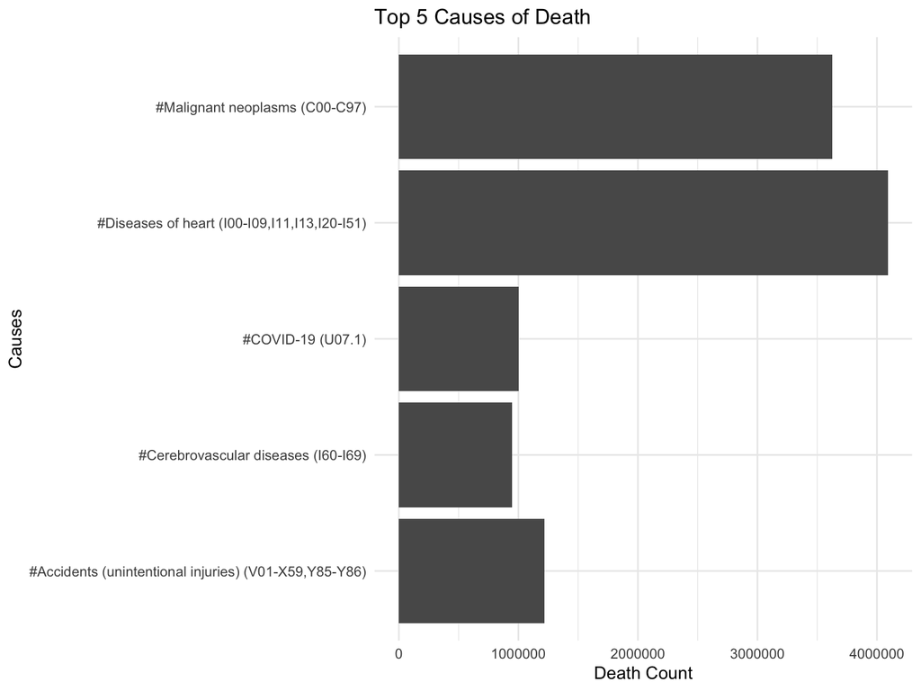

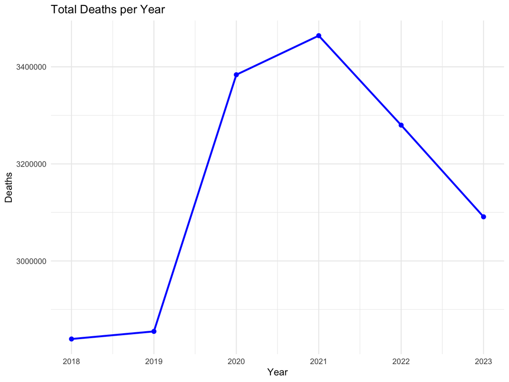

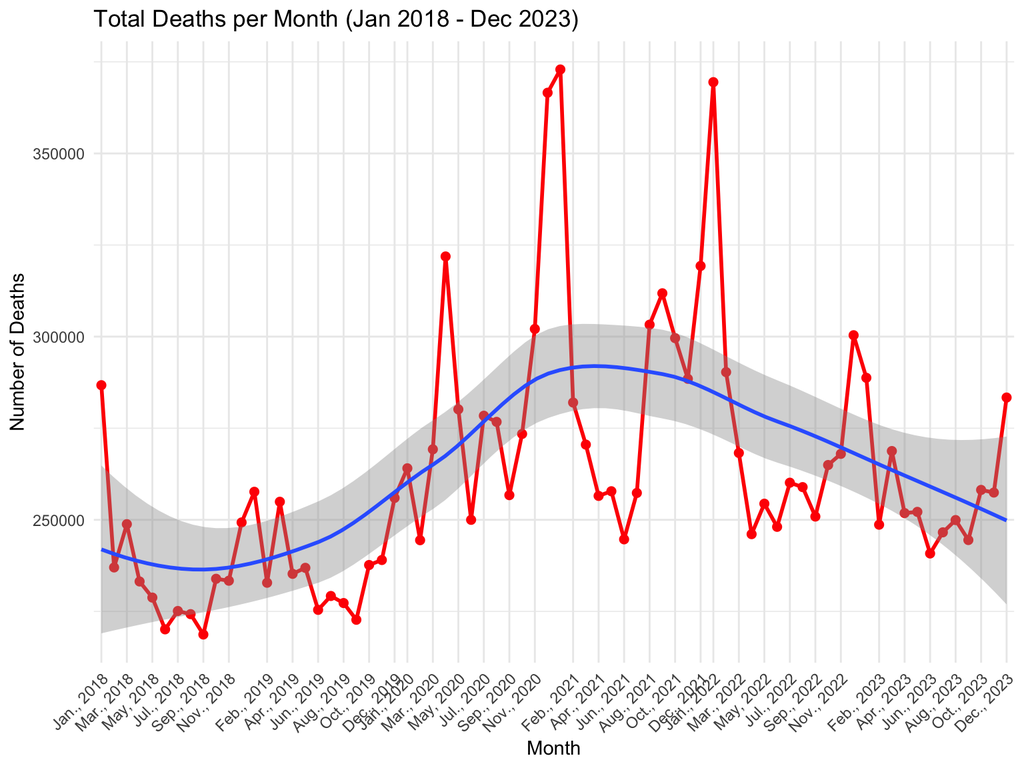

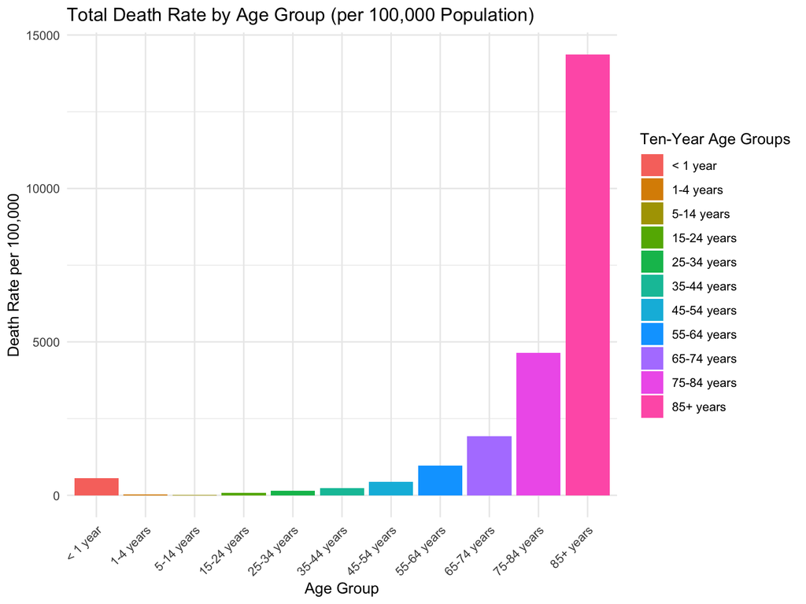

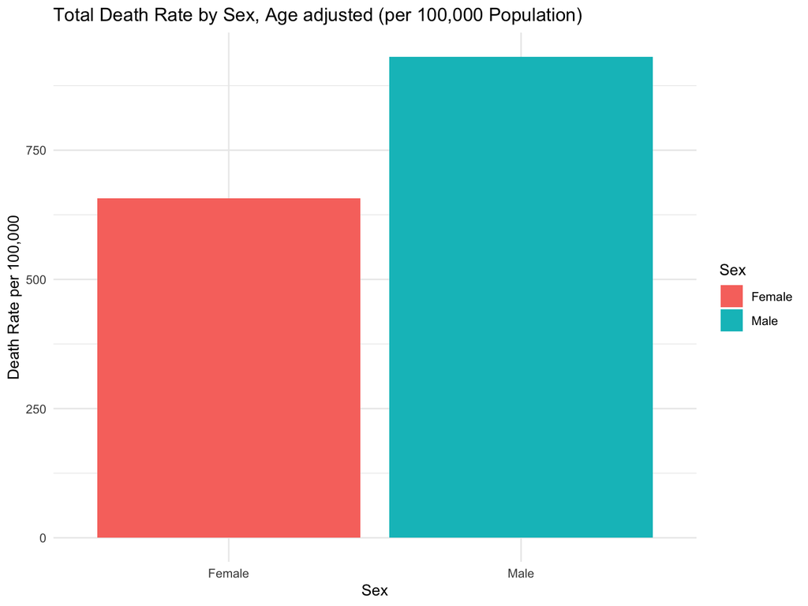

# Multinomial Model

Build a multinomial logistic regression model to assess the relationship between: - Sex - Education level - Sex × Education interaction - and the Cause of Death (6 categories; “Others” as reference) Data & Model Setup - Used aggregated data with weights = Deaths to account for population size

# Normal

```r
summary(model)
```

```
##
## Call:
## vglm(formula = Cause ~ Sex + Education, family = multinomial(refLevel = "Others"),
##     data = data_mult_filtered, weights = Deaths)
##
## Coefficients:
##                                                                                 Estimate
## (Intercept):1                                                                  -2.530719
## (Intercept):2                                                                  -2.047735
## (Intercept):3                                                                  -1.859934
## (Intercept):4                                                                  -0.969791
## (Intercept):5                                                                  -1.281990
## SexMale:1                                                                       0.720607
## SexMale:2                                                                      -0.250613
## SexMale:3                                                                       0.267650
## SexMale:4                                                                       0.224289
## SexMale:5                                                                       0.114091
## Education9th through 12th grade with no diploma:1                               0.669946
## Education9th through 12th grade with no diploma:2                              -0.052024
## Education9th through 12th grade with no diploma:3                              -0.085183
## Education9th through 12th grade with no diploma:4                               0.131479
## Education9th through 12th grade with no diploma:5                               0.280108
## EducationAssociate degree (AA,AS):1                                             0.214076
## EducationAssociate degree (AA,AS):2                                             0.028045
## EducationAssociate degree (AA,AS):3                                            -0.036153
## EducationAssociate degree (AA,AS):4                                             0.182022
## EducationAssociate degree (AA,AS):5                                             0.577124
## EducationBachelor’s degree (BA, AB, BS):1                                      -0.044268
## EducationBachelor’s degree (BA, AB, BS):2                                       0.123135
## EducationBachelor’s degree (BA, AB, BS):3                                      -0.252318
## EducationBachelor’s degree (BA, AB, BS):4                                       0.184427
## EducationBachelor’s degree (BA, AB, BS):5                                       0.602839
## EducationDoctorate (PhD, EdD) or Professional Degree (MD, DDS, DVM, LLB, JD):1 -0.326530
## EducationDoctorate (PhD, EdD) or Professional Degree (MD, DDS, DVM, LLB, JD):2  0.263203
## EducationDoctorate (PhD, EdD) or Professional Degree (MD, DDS, DVM, LLB, JD):3 -0.434783
## EducationDoctorate (PhD, EdD) or Professional Degree (MD, DDS, DVM, LLB, JD):4  0.187594
## EducationDoctorate (PhD, EdD) or Professional Degree (MD, DDS, DVM, LLB, JD):5  0.607332
## EducationHigh school graduate or GED completed:1                                0.387976
## EducationHigh school graduate or GED completed:2                                0.034524
## EducationHigh school graduate or GED completed:3                               -0.098112
```

[output cut: 200 more lines]

```
##
## Names of linear predictors: log(mu[,2]/mu[,1]), log(mu[,3]/mu[,1]),
## log(mu[,4]/mu[,1]), log(mu[,5]/mu[,1]), log(mu[,6]/mu[,1])
##
## Residual deviance: 29130048 on 3990 degrees of freedom
##
## Log-likelihood: -14565024 on 3990 degrees of freedom
##
## Number of Fisher scoring iterations: 5
##
## Warning: Hauck-Donner effect detected in the following estimate(s):
## '(Intercept):1'
##
##
## Reference group is level  1  of the response
```

# Normal + interaction

```r
summary(model_interaction)
```

```
##
## Call:
## vglm(formula = Cause ~ Sex + Education + Education * Sex, family = multinomial(refLevel = "Others"),
##     data = data_mult_filtered, weights = Deaths)
##
## Coefficients:
##                                                                                         Estimate
## (Intercept):1                                                                          -2.553467
## (Intercept):2                                                                          -2.053768
## (Intercept):3                                                                          -1.883343
## (Intercept):4                                                                          -0.902293
## (Intercept):5                                                                          -1.360822
## SexMale:1                                                                               0.755071
## SexMale:2                                                                              -0.236534
## SexMale:3                                                                               0.309726
## SexMale:4                                                                               0.095949
## SexMale:5                                                                               0.262150
## Education9th through 12th grade with no diploma:1                                       0.634556
## Education9th through 12th grade with no diploma:2                                      -0.032193
## Education9th through 12th grade with no diploma:3                                       0.027504
## Education9th through 12th grade with no diploma:4                                       0.115174
## Education9th through 12th grade with no diploma:5                                       0.316029
## EducationAssociate degree (AA,AS):1                                                     0.337669
## EducationAssociate degree (AA,AS):2                                                     0.027785
## EducationAssociate degree (AA,AS):3                                                    -0.024442
## EducationAssociate degree (AA,AS):4                                                     0.089600
## EducationAssociate degree (AA,AS):5                                                     0.674205
## EducationBachelor’s degree (BA, AB, BS):1                                               0.195392
## EducationBachelor’s degree (BA, AB, BS):2                                               0.108679
## EducationBachelor’s degree (BA, AB, BS):3                                              -0.282749
## EducationBachelor’s degree (BA, AB, BS):4                                               0.067575
## EducationBachelor’s degree (BA, AB, BS):5                                               0.753385
## EducationDoctorate (PhD, EdD) or Professional Degree (MD, DDS, DVM, LLB, JD):1          0.162922
## EducationDoctorate (PhD, EdD) or Professional Degree (MD, DDS, DVM, LLB, JD):2          0.147286
## EducationDoctorate (PhD, EdD) or Professional Degree (MD, DDS, DVM, LLB, JD):3         -0.409747
## EducationDoctorate (PhD, EdD) or Professional Degree (MD, DDS, DVM, LLB, JD):4          0.012928
## EducationDoctorate (PhD, EdD) or Professional Degree (MD, DDS, DVM, LLB, JD):5          0.945014
## EducationHigh school graduate or GED completed:1                                        0.318295
## EducationHigh school graduate or GED completed:2                                        0.052625
## EducationHigh school graduate or GED completed:3                                       -0.071044
```

[output cut: 375 more lines]

```
##
## Names of linear predictors: log(mu[,2]/mu[,1]), log(mu[,3]/mu[,1]),
## log(mu[,4]/mu[,1]), log(mu[,5]/mu[,1]), log(mu[,6]/mu[,1])
##
## Residual deviance: 29118439 on 3955 degrees of freedom
##
## Log-likelihood: -14559219 on 3955 degrees of freedom
##
## Number of Fisher scoring iterations: 5
##
## Warning: Hauck-Donner effect detected in the following estimate(s):
## '(Intercept):1'
##
##
## Reference group is level  1  of the response
```

# Compare

```r
logLik(model)
```

```
## [1] -14565024
```

```r
logLik(model_interaction)
```

```
## [1] -14559219
```

```r
AIC(model)
```

```
## [1] 29130138
```

```r
AIC(model_interaction)
```

```
## [1] 29118599
```

- Model 1: Cause ~ Sex + Education
- Model 2: Cause ~ Sex * Education (includes interaction)

Key Results Model 2 (with interaction) had: - Lower AIC → better fit - All coefficients statistically significant

# Transforming external Micro-Census Data to fit ours

- IPUMS CPS: Why and how we used it:
  - IPUMS CPS = National survey with & individual level Data
    - contains Information on Education
  - Used to estimate education distributions by Age Groups & Sex
  - Merged proportions into CDC mortality data
  - Helped us reconstruct population size by education
  - Helpful for education-focused mortality-rate modeling

# Transforming external Micro-Census Data to fit ours

- Why:
  - Lack of population for Education Groups, when grouped by Age & Sex
- Solution: Merge IPUMS CPS population Data to estimate education structure

# Building the Dataset

- Step 1: Clean CPS Data
  - Recode Education level to fit the ones from CDC
  - Group by Age x Sex x Education
  - Use weights within Dataset to estimate the population
- Step 2: Match with CDC
  - Compare CPS population grouped by Age x Sex with CDC population
  - Adjust each population group to match the CDC Age x Sex population

# Final Data

- Data containing the population for Age x Sex x Education => We can now analyse death rates
- 10 Year Age Groups, with 85+ as last Age Group
- Use Ages > 24 to model, to interpret highest educational attainment as socio-economic status

# Negative Binomial Model